# Minería de datos: PEC2 - Métodos no supervisados

Autor: Alberto Sánchez Mazarro

Abril 2020

## Ejercicio 1.1

Tomando como punto de partida los ejemplos mostrados, realizar un estudio similar con otro conjunto de datos. Pueden ser datos reales de vuestro ámbito laboral o de algún repositorio de datos de Internet. Mirad por ejemplo: http://www.ics.uci.edu/~mlearn/MLSummary.html.

A la hora de elegir la base de datos ten en cuenta que sea apropiada para problemas no supervisados y que los atributos sean también apropiados para su uso con el algoritmo kmeans.

No hay que olvidarse de la fase de preparación y análisis de datos.

### Respuesta 1.1:

El dataset elegido para el estudio ha sido “Wholesale Customers” (http://archive.ics.uci.edu/ml/datasets/Wholesale+customers), que está especialmente recomendado para problemas de clustering.

En él se presenta un conjunto de datos numéricos con las siguientes características:

8 atributos:

1. CHANNEL: Horeca (Hotel/Restaurant/CafÃ©) or Retail channel (Nominal)
2. REGION: Lisnon, Oporto or Other (Nominal)
3. FRESH: annual spending (m.u.) on fresh products (Continuous);
4. MILK: annual spending (m.u.) on milk products (Continuous);
5. GROCERY: annual spending (m.u.)on grocery products (Continuous);
6. FROZEN: annual spending (m.u.)on frozen products (Continuous)
7. DETERGENTS_PAPER: annual spending (m.u.) on detergents and paper products (Continuous)
8. DELICATESSEN: annual spending (m.u.)on and delicatessen products (Continuous);

De ellos, los 6 últimos atributos indican el gasto en unidades monetarias del establecimiento (diremos euros, por simplificar) y los dos primeros son variables de clase , donde “Channel” indican si el establecimiento es “Hotel/Restaurante” o “Retail” y “Region” indica si se está ubicada en el área de Lisboa, Oporto u otra.

Lo primero que hago es cargar las librerías, que se usarán a lo largo del ejercicio.

```r
library(cluster)
library(dplyr)
library(class)
```

Posteriormente cargo el dataset y consulto su aspecto.

```r
datos <- read.csv('/Users/Alberto/UOC/Minería/PEC2/Wholesale customers data.csv',stringsAsFactors = FALSE, header = TRUE)

#Copio los datos sin ninguna manipulación por si los tengo que recuperar más adelante.
datosCopia <- datos

datos$Channel <- gsub('1', 'Hotel', datos$Channel )
datos$Channel <- gsub('2', 'Retail', datos$Channel )
datos$Channel <- as.factor(datos$Channel)

summary(datos)
```

```
##    Channel        Region          Fresh             Milk          Grocery
##  Hotel :298   Min.   :1.000   Min.   :     3   Min.   :   55   Min.   :    3
##  Retail:142   1st Qu.:2.000   1st Qu.:  3128   1st Qu.: 1533   1st Qu.: 2153
##               Median :3.000   Median :  8504   Median : 3627   Median : 4756
##               Mean   :2.543   Mean   : 12000   Mean   : 5796   Mean   : 7951
##               3rd Qu.:3.000   3rd Qu.: 16934   3rd Qu.: 7190   3rd Qu.:10656
##               Max.   :3.000   Max.   :112151   Max.   :73498   Max.   :92780
##      Frozen        Detergents_Paper    Delicassen
##  Min.   :   25.0   Min.   :    3.0   Min.   :    3.0
##  1st Qu.:  742.2   1st Qu.:  256.8   1st Qu.:  408.2
##  Median : 1526.0   Median :  816.5   Median :  965.5
##  Mean   : 3071.9   Mean   : 2881.5   Mean   : 1524.9
##  3rd Qu.: 3554.2   3rd Qu.: 3922.0   3rd Qu.: 1820.2
##  Max.   :60869.0   Max.   :40827.0   Max.   :47943.0
```

```r
str(datos)
```

```
## 'data.frame':    440 obs. of  8 variables:
##  $ Channel         : Factor w/ 2 levels "Hotel","Retail": 2 2 2 1 2 2 2 2 1 2 ...
##  $ Region          : int  3 3 3 3 3 3 3 3 3 3 ...
##  $ Fresh           : int  12669 7057 6353 13265 22615 9413 12126 7579 5963 6006 ...
##  $ Milk            : int  9656 9810 8808 1196 5410 8259 3199 4956 3648 11093 ...
##  $ Grocery         : int  7561 9568 7684 4221 7198 5126 6975 9426 6192 18881 ...
##  $ Frozen          : int  214 1762 2405 6404 3915 666 480 1669 425 1159 ...
##  $ Detergents_Paper: int  2674 3293 3516 507 1777 1795 3140 3321 1716 7425 ...
##  $ Delicassen      : int  1338 1776 7844 1788 5185 1451 545 2566 750 2098 ...
```

Como las variables “Region” y “Channel” son categóricas y de clase, las elimino. Luego me pueden servir para hacer estimaciones de la calidad del algoritmo.

```r
datosAnalisis <- select(datos, Fresh, Milk, Grocery, Frozen, Detergents_Paper, Delicassen)
summary(datos)
```

```
##    Channel        Region          Fresh             Milk          Grocery
##  Hotel :298   Min.   :1.000   Min.   :     3   Min.   :   55   Min.   :    3
##  Retail:142   1st Qu.:2.000   1st Qu.:  3128   1st Qu.: 1533   1st Qu.: 2153
##               Median :3.000   Median :  8504   Median : 3627   Median : 4756
##               Mean   :2.543   Mean   : 12000   Mean   : 5796   Mean   : 7951
##               3rd Qu.:3.000   3rd Qu.: 16934   3rd Qu.: 7190   3rd Qu.:10656
##               Max.   :3.000   Max.   :112151   Max.   :73498   Max.   :92780
##      Frozen        Detergents_Paper    Delicassen
##  Min.   :   25.0   Min.   :    3.0   Min.   :    3.0
##  1st Qu.:  742.2   1st Qu.:  256.8   1st Qu.:  408.2
##  Median : 1526.0   Median :  816.5   Median :  965.5
##  Mean   : 3071.9   Mean   : 2881.5   Mean   : 1524.9
##  3rd Qu.: 3554.2   3rd Qu.: 3922.0   3rd Qu.: 1820.2
##  Max.   :60869.0   Max.   :40827.0   Max.   :47943.0
```

Me surge la curiosidad de ver la diferencia de comportamiento del algoritmo sin normalizar los datos y normalizándolos, así que voy a hacer una primera ejecución del algoritmo k-means con los datos originales.

Usamos la función daisy para calcular la matriz de similitud. Como k-means necesita conocer a priori el número de conjuntos que se buscan, calculo la silueta para k entre 2 y 10 (el número de agrupaciones deseadas) y vemos cuál es su mejor valor

```r
matDist <- daisy(datosAnalisis)
resultadosDaisy <- rep(0, 10)
resultadosCodo <- rep(0, 10)
for (i in c(2,3,4,5,6,7,8,9,10))
{
  ajuste           <- kmeans(datosAnalisis, i)
  y_cluster     <- ajuste$cluster
  resultadosCodo[i] <- ajuste$tot.withinss
  silueta            <- silhouette(y_cluster, matDist)
  resultadosDaisy[i] <- mean(silueta[,3])

}
```

Vamos a ver gráficamente la función de la silueta en función del número de conjuntos que tomemos con el método de la silueta.

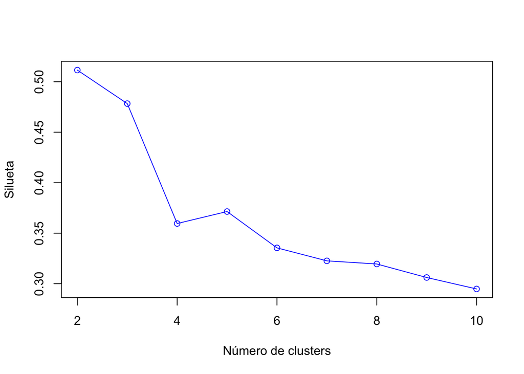

```r
plot(2:10,resultadosDaisy[2:10],type="o",col="blue",xlab="Número de clusters",ylab="Silueta")
```

Esto parece indicar que el número óptimo de conjuntos es 2 (lo cual es bastante lógico sabiendo que partíamos de un conjunto que tenía dos valores de clase como eran Restauración y Retail). Sin embargo, observamos que para 3 conjuntos el valor de la silueta es relativamente similar, pero a partir de 4 ya es significativamente más bajo.

Vamos a ver qué sucede utilizando el método del codo.

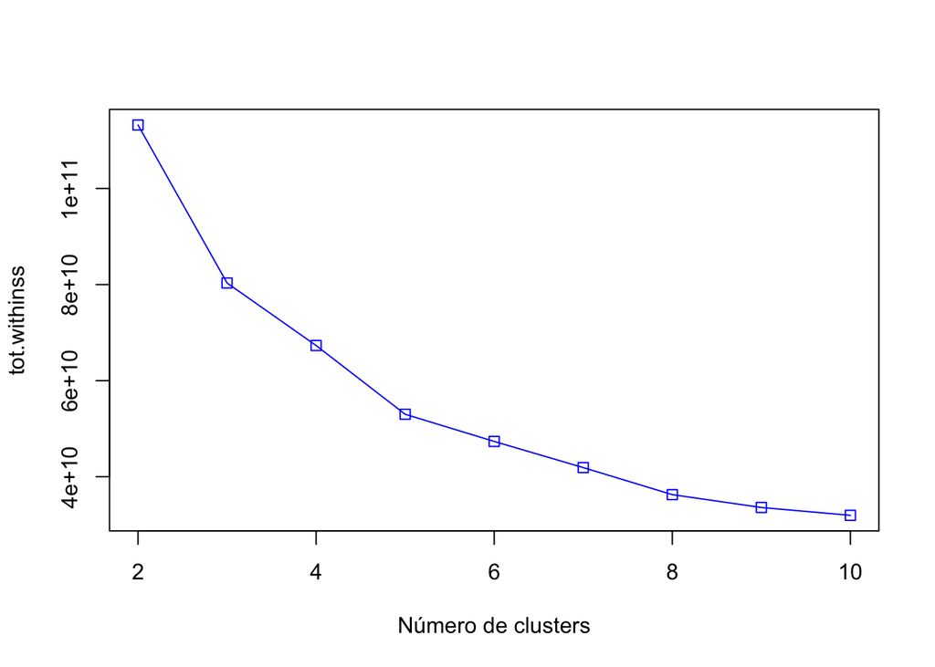

```r
plot(2:10,resultadosCodo[2:10],type="o",col="blue",pch=0,xlab="Número de clusters",ylab="tot.withinss")
```

Parece que se estabiliza en el valor 4 o 5 (depende de la ejecución).

Por último vamos a ver cómo de buena es la agrupación que ha hecho el algoritmo k means para el valor k=2 con respecto a si un elemento del conjunto pertenece a “Hostelería” o “Retail”

```r
dosClusters <- kmeans(datosAnalisis, 2)
table(dosClusters$cluster,datos$Channel)
```

```
##
##     Hotel Retail
##   1    51     14
##   2   247    128
```

Por lo que el porcentaje de precisión es

```r
100* (247 + 14) / (440)
```

```
## [1] 59.31818
```

El resultado no es del todo satisfactorio.

A continuación vamos a hacer los mismos cálculos pero con los datos normalizados para k=2.

```r
datosNormalizados <- datosAnalisis
normalizar <- function(x){(x-min(x))/(max(x)-min(x))}
#Normalizo los valores de cada columna.
for (i in c(1,2,3,4,5,6))
{
datosNormalizados[i] <- normalizar(datosNormalizados[i])
}

#Observamos los valores de la silueta cuando los valores está normalizados

matDistNorm <- daisy(datosNormalizados)
dosClustersNorm <- kmeans(datosNormalizados, 2)
siluetaNorm <- silhouette(dosClustersNorm$cluster, matDistNorm)

##Con lo que el valor de la silueta vemos que es ligeramente superior al que obtuvimos para k=2 sin normalizar (ver primer gráfico)
mean(siluetaNorm[,3])
```

```
## [1] 0.5729735
```

Observamos que la silueta parece tener un valor más alto con los datos normalizados que con los datos estándar

```r
table(dosClustersNorm$cluster,datos$Channel)
```

```
##
##     Hotel Retail
##   1   296     98
##   2     2     44
```

Por lo que el porcentaje de precisión es

```r
100* (296 + 44) / (440)
```

```
## [1] 77.27273
```

y parece mejorar significativamente.

## Ejercicio 1.2

Buscar información sobre otros métodos de agregación diferentes al Kmeans. Partiendo del ejercicio anterior probar el funcionamiento de al menos 2 métodos diferentes y comparar los resultados obtenidos.

### Respuesta 1.2

Voy a intentar utilizar el método KNN (K vecinos próximos).

Vamos a separar en dos conjuntos (entrenamiento y prueba) la muestra. Tomo un 70% para el entrenamiento y un 30 para la prueba.

```r
datosKNN<-datosCopia
indices <- sample(1:nrow(datosKNN),as.integer(0.7*nrow(datosKNN)))
datosTrain <- datosKNN[indices,]
datosTest <- datosKNN[-indices,]
#Extraigo el argumento de clase por el que vamos a clasificar (parámetro requerido del algoritmo, que será "Channel" (columna 1))
claseTrain <- datosKNN[-indices,1]
claseTarget <- datosKNN[indices,1]
```

Ejecutamos el algoritmo

```r
vecinos2 <- knn(datosTrain,datosTest,cl=claseTarget, k=2)
tab <- table(vecinos2,claseTrain)
table(vecinos2)
```

```
## vecinos2
##  1  2
## 97 35
```

Ahora vamos a ver la calidad del algoritmo para generar dos grupos en base al criterio de similitud por el tipo de establecimiento (Hostelería o Retail)

```r
fiabilidad <- function(x){sum(diag(x)/(sum(rowSums(x)))) * 100}
fiabilidad(tab)
```

```
## [1] 84.84848
```

Vemos que desde el punto de vista de la clasificación es mejor que el que anteriormente habíamos ejecutado con k-means. Es lógico, puesto que aquí hemos agrupado por similitud a un objetivo concreto (el atributo Channel, mientras que antes estábamos agrupando por “similitud general”)

A continuación voy a probar con otro método de “clustering jerárquico” utilizando la función hclust.

La idea es intentar ver bajo qué criterios de similitud se pueden ir agrupando los datos que tenemos. Para ello, voy a volver al dataset normalizado (datosNormalizados) que ya utilicé en el ejercicio anterior.

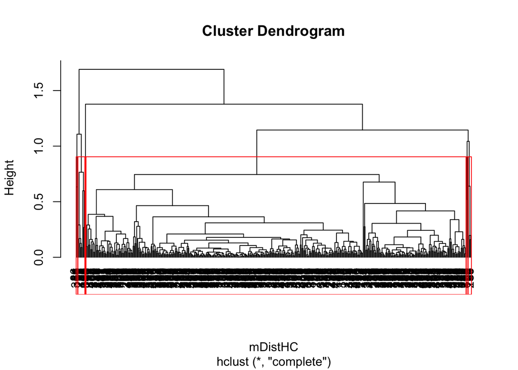

```r
#Calculo la matriz distancia

mDistHC <- dist (as.matrix(datosNormalizados))
#Aplico el algoritmo
ajusteHC <- hclust (mDistHC)
#Muestro el diagrama
plot (ajusteHC, hang=-1)

#Intento mostrar en bordes rojos los dos grupos
rect.hclust(ajusteHC, k=6, border="red") # pintamos el gráfico
```

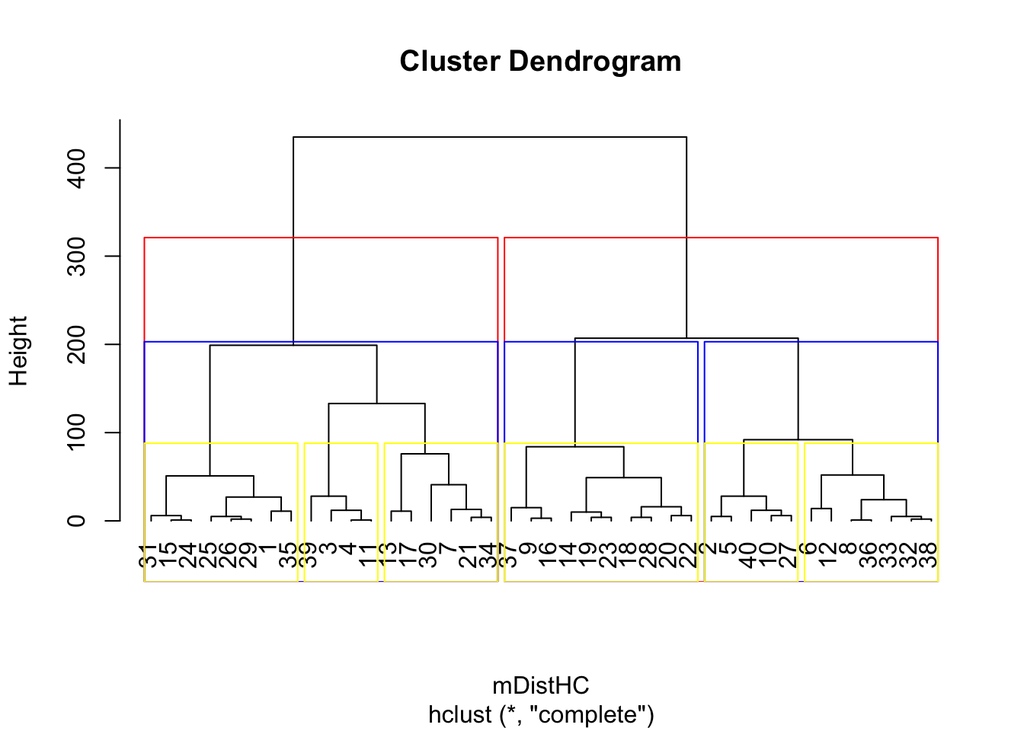

```r
muestra <- sample(1:dim(datosNormalizados)[1], 40)
mDistHC <- dist (as.matrix(muestra))
#Aplico el algoritmo
ajusteHC <- hclust (mDistHC)
#Muestro el diagrama
plot (ajusteHC, hang=-1)

#Intento mostrar en bordes rojos los dos grupos
rect.hclust(ajusteHC, k=2, border="red") # pintamos el gráfico

#Ahora para 3 grupos
rect.hclust(ajusteHC, k=3, border="blue") # pintamos el gráfico

#Ahora para 6
rect.hclust(ajusteHC, k=6, border="yellow") # pintamos el gráfico
```

## Ejercicio 2.1:

En este ejercicio seguiréis los pasos del ciclo de vida de un proyecto de minería de datos para el caso de un algoritmo de generación de reglas de asociación. Lo haréis con el fichero Lastfm.csv que encontraréis adjunto. Este fichero contiene un conjunto de registros. Estos registros son el histórico de las canciones que ha escuchado un usuario (user) en un portal Web de música. “artist” es el nombre del grupo que ha escuchado, sex y country corresponden a variables que describen al usuario.

### Respuesta 2.1:

Empezamos por cargar el dataset.

```r
library(arules)
datosFM <- read.csv('/Users/Alberto/UOC/Minería/PEC2/lastfm.csv',stringsAsFactors = FALSE, header = TRUE)
str (datosFM)
```

```
## 'data.frame':    289955 obs. of  4 variables:
##  $ user   : int  1 1 1 1 1 1 1 1 1 1 ...
##  $ artist : chr  "red hot chili peppers" "the black dahlia murder" "goldfrapp" "dropkick murphys" ...
##  $ sex    : chr  "f" "f" "f" "f" ...
##  $ country: chr  "Germany" "Germany" "Germany" "Germany" ...
```

```r
summary(datosFM)
```

```
##       user          artist              sex              country
##  Min.   :    1   Length:289955      Length:289955      Length:289955
##  1st Qu.: 4935   Class :character   Class :character   Class :character
##  Median : 9838   Mode  :character   Mode  :character   Mode  :character
##  Mean   : 9852
##  3rd Qu.:14769
##  Max.   :19718
```

```r
datosFMaux<-datosFM
```

Observo que con la estructura inicial del dataset no puedo hacer las manipulaciones del ejercicio, así que manipulo los datos para poder llevar a cabo el estudio. La idea es agrupar las escuchas de cada usuario.

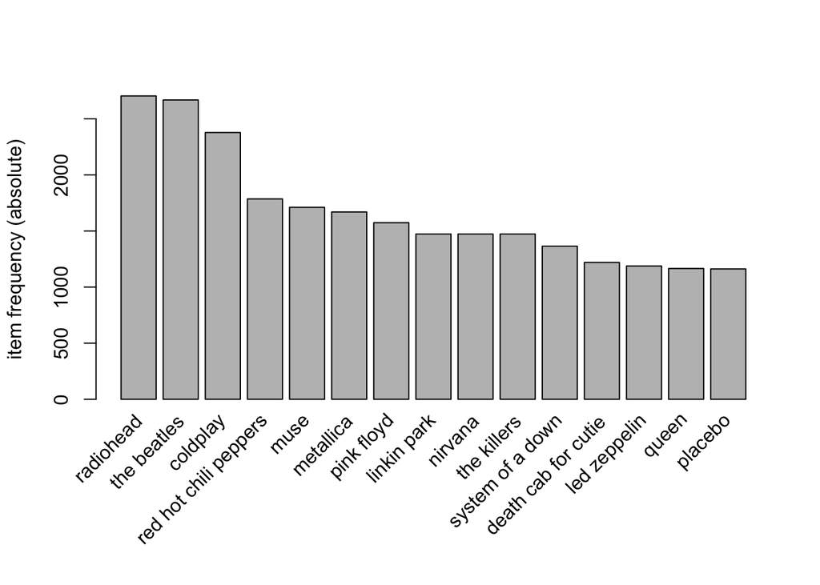

```r
#Convierto a factor el código de usuario.
datosFMaux$user <- factor(datosFMaux$user)

#Agrupo escuchas por usuario
lista <- split (x=datosFMaux[,"artist"], f= datosFMaux$user)

#Elimino los duplicados
lista <- lapply(lista,unique)

#Agrupamos los elementos en transacciones para poder pintar el gráfico
lista <- as(lista,"transactions")

#Y muestro el top 15 de más escuchados en la lista
itemFrequencyPlot(lista, topN=15, type="absolute")
```

Ejecutamos el algoritmo a priori para ver qué objetos se asocian entre sí (previsiblemente estilos parecidos)

```r
#Pongo un soporte del 1% y una confianza del 50
reglas<- apriori(lista, parameter = list(support = 0.01, confidence = 0.5))
```

```
## Apriori
##
## Parameter specification:
##  confidence minval smax arem  aval originalSupport maxtime support minlen
##         0.5    0.1    1 none FALSE            TRUE       5    0.01      1
##  maxlen target   ext
##      10  rules FALSE
##
## Algorithmic control:
##  filter tree heap memopt load sort verbose
##     0.1 TRUE TRUE  FALSE TRUE    2    TRUE
##
## Absolute minimum support count: 150
##
## set item appearances ...[0 item(s)] done [0.00s].
## set transactions ...[1004 item(s), 15000 transaction(s)] done [0.08s].
## sorting and recoding items ... [655 item(s)] done [0.01s].
## creating transaction tree ... done [0.01s].
## checking subsets of size 1 2 3 4 done [0.04s].
## writing ... [50 rule(s)] done [0.00s].
## creating S4 object  ... done [0.00s].
```

```r
#Ordeno las reglas por confianza, por soporte y por lift
inspect(head(sort(reglas, by = "confidence"), 5))
```

```
##     lhs                                 rhs         support    confidence
## [1] {oasis,the killers}              => {coldplay}  0.01113333 0.6626984
## [2] {sigur rós,the beatles}          => {radiohead} 0.01046667 0.6434426
## [3] {keane}                          => {coldplay}  0.02226667 0.6374046
## [4] {radiohead,snow patrol}          => {coldplay}  0.01006667 0.6344538
## [5] {coldplay,the smashing pumpkins} => {radiohead} 0.01093333 0.6283525
##     lift     count
## [1] 4.180183 167
## [2] 3.569393 157
## [3] 4.020634 334
## [4] 4.002021 151
## [5] 3.485683 164
```

Lo cual da unos resultados bastante “coherentes” ordenando por ambos criterios.

Ordenando por confianza, la primera fila indica {oasis,the killers} => {coldplay} lo cual no es sorprendente, pues son 3 grupos de música ingleses de pop-rock.

```r
inspect(head(sort(reglas, by = "support"), 5))
```

```
##     lhs              rhs         support    confidence lift     count
## [1] {beck}        => {radiohead} 0.02926667 0.5092807  2.825152 439
## [2] {snow patrol} => {coldplay}  0.02646667 0.5251323  3.312441 397
## [3] {keane}       => {coldplay}  0.02226667 0.6374046  4.020634 334
## [4] {blur}        => {radiohead} 0.01753333 0.5228628  2.900496 263
## [5] {megadeth}    => {metallica} 0.01626667 0.5281385  4.743759 244
```

Por soporte, {beck} => {radiohead} lo cual tampoco sorprende en exceso.

```r
inspect(head(sort(reglas, by = "lift"), 5))
```

```
##     lhs                       rhs            support    confidence lift
## [1] {the pussycat dolls}   => {rihanna}      0.01040000 0.5777778  13.415893
## [2] {t.i.}                 => {kanye west}   0.01040000 0.5672727   8.854413
## [3] {judas priest}         => {iron maiden}  0.01353333 0.5075000   8.562992
## [4] {sonata arctica}       => {nightwish}    0.01346667 0.5101010   8.236292
## [5] {pink floyd,the doors} => {led zeppelin} 0.01066667 0.5387205   6.802027
##     count
## [1] 156
## [2] 156
## [3] 203
## [4] 202
## [5] 160
```

También se ofrecen resultados esperables y se observa cómo ambas columnas muestran artistas “similares”.

Por curiosidad, voy a ver qué sucede en España, aunque es utilizar las mismas operaciones con un conjunto de datos más pequeño

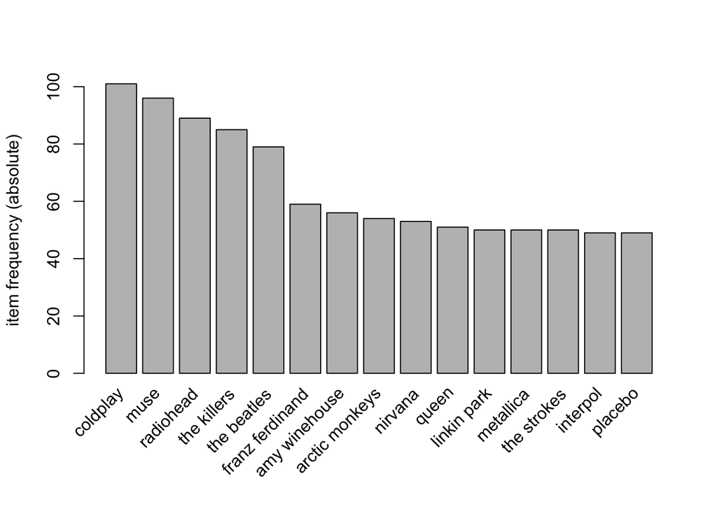

```r
datosSpain<-datosFM
datosSpain$country <- factor(datosSpain$country)
datosSpain<-filter(datosSpain, country=="Spain")

#Agrupo escuchas por usuario
listaSpain <- split (x=datosSpain[,"artist"], f= datosSpain$user)

#Elimino los duplicados
listaSpain <- lapply(listaSpain,unique)

#Agrupamos los elementos en transacciones para poder pintar el gráfico
listaSpain <- as(listaSpain,"transactions")

#Y muestro el top 15 de más escuchados en la lista
itemFrequencyPlot(listaSpain, topN=15, type="absolute")
```

Vemos que en España hay algunos cambios entre los 15 más escuchados con respecto a la muestra global.

Veamos ahora las relaciones:

```r
reglasSpain<- apriori(listaSpain, parameter = list(support = 0.01, confidence = 0.4))
```

```
## Apriori
##
## Parameter specification:
##  confidence minval smax arem  aval originalSupport maxtime support minlen
##         0.4    0.1    1 none FALSE            TRUE       5    0.01      1
##  maxlen target   ext
##      10  rules FALSE
##
## Algorithmic control:
##  filter tree heap memopt load sort verbose
##     0.1 TRUE TRUE  FALSE TRUE    2    TRUE
##
## Absolute minimum support count: 5
##
## set item appearances ...[0 item(s)] done [0.00s].
## set transactions ...[944 item(s), 506 transaction(s)] done [0.00s].
## sorting and recoding items ... [532 item(s)] done [0.00s].
## creating transaction tree ... done [0.00s].
## checking subsets of size 1 2 3 4 5 6 7 8 done [0.01s].
## writing ... [14963 rule(s)] done [0.00s].
## creating S4 object  ... done [0.00s].
```

```r
inspect(head(sort(reglasSpain, by = "support"), 5))
```

```
##     lhs              rhs           support    confidence lift     count
## [1] {the killers} => {coldplay}    0.08893281 0.5294118  2.652301 45
## [2] {coldplay}    => {the killers} 0.08893281 0.4455446  2.652301 45
## [3] {muse}        => {coldplay}    0.07905138 0.4166667  2.087459 40
## [4] {radiohead}   => {coldplay}    0.07707510 0.4382022  2.195350 39
## [5] {the killers} => {muse}        0.07509881 0.4470588  2.356373 38
```

```r
inspect(head(sort(reglasSpain, by = "confidence"), 5))
```

```
##     lhs                         rhs             support    confidence lift
## [1] {mudvayne}               => {slipknot}      0.01383399 1          22.000000
## [2] {anti-flag,sum 41}       => {blink-182}     0.01185771 1          17.448276
## [3] {anti-flag,blink-182}    => {sum 41}        0.01185771 1          22.000000
## [4] {beyoncé,jennifer lopez} => {rihanna}       0.01185771 1          22.000000
## [5] {coldplay,duffy}         => {amy winehouse} 0.01185771 1           9.035714
##     count
## [1] 7
## [2] 6
## [3] 6
## [4] 6
## [5] 6
```

```r
inspect(head(sort(reglasSpain, by = "lift"), 5))
```

```
##     lhs                                   rhs            support    confidence
## [1] {mastodon,trivium}                 => {machine head} 0.01185771 1.000
## [2] {mastodon,metallica}               => {machine head} 0.01383399 1.000
## [3] {christina aguilera,kylie minogue} => {mariah carey} 0.01383399 0.875
## [4] {slipknot,system of a down}        => {mudvayne}     0.01185771 0.500
## [5] {in flames,machine head}           => {mastodon}     0.01185771 1.000
##     lift     count
## [1] 42.16667 6
## [2] 42.16667 7
## [3] 40.25000 7
## [4] 36.14286 6
## [5] 36.14286 6
```

De nuevo vemos que, aunque los artistas cambian, el estilo de antecedentes y consecuentes se puede considerar semejante.

Este tratamiento entiendo que puede ser de mucha utilidad, por ejemplo, en algún programa de recomendación musical a usuarios suscritos a una plataforma. Cuando llega un usuario nuevo, en función de sus primeras escuchas se le pueden anticipar algunas sugerencias de música que muy probablemente le puede gustar.